# CSCI_E-89C_Midterm_part2

## Problem 1

In this problem, we consider the optimal selection of a treatment. Suppose that there are 5 types of treatments available. The outcome of each treatment is either 1 (recovery) or 0.

Let's denote the outcome by $R_t$, then $R_t|(A_t=a)$ follows $\text{Bernoulli}(p_a)$ with $a\in\{1,2,3,4,5\}$ and all $p_a\in [0,1]$, where $A_t$ denotes the action on time step $t=1,2,3,\ldots$.

Assume that $p_1=0.1$, $p_2=0.3$, $p_3=0.5$, $p_4=0.7$, $p_5=0.9$, which are not known to the doctor. This is the 5-armed Bandit Problem with Bernoulli distributions. The rewards $R_t$ are 0's and 1's. Please notice that $P\{R_t=1|A_t=a\}=p_a$. Also, the expectation $E\left[R_t|A_t=a \right]=p_a$.

Develop the Optimistic Initial Values algorithm for the problem of selecting the best treatment and report the following graphs:  
(a) Run the algorithm for $t=1,2,3,\ldots,200$ and plot $R_t$'s v.s. $t$ for one simulation.  
(b) Run the trajectory in (a) for 100 epochs; and for each time step $t$ plot the average of $R_t$'s from the epochs at time particular time (please do not average all returns over time - we want to see how the learning progresses over time).  
(c) Using trajectories you obtained in (b), for each time step $t$, plot the proportion (out of 100) of times the best action (action $a=5$) was selected by the doctor.

```
(a)
```

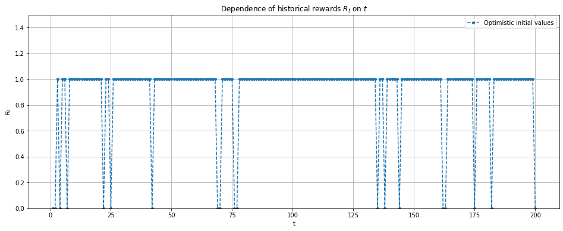

```
(b)
```

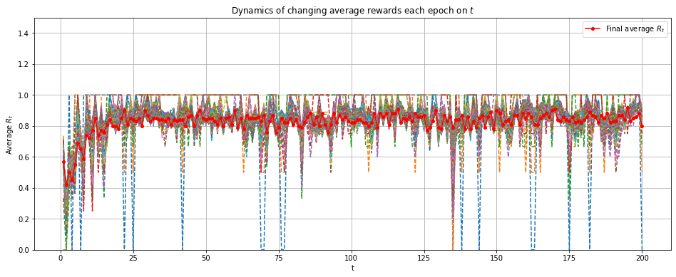

```
(c)
```

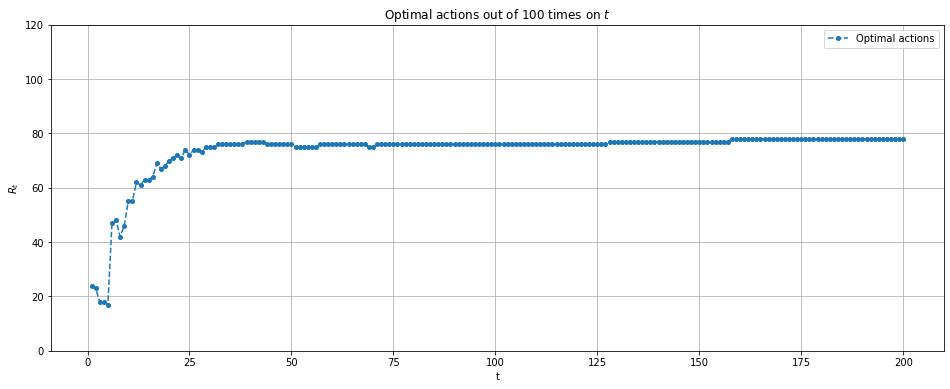

```python
import numpy as np
from matplotlib import pyplot as plt

class Environment:
    def __init__(self):
        self.time = 1

    def admissible_actions(self):
        return list(range(1,6))

    def get_reward(self, action):

        P = [[0.9,0.1],
             [0.7,0.3],
             [0.5,0.5],
             [0.3,0.7],
             [0.1,0.9]]

        self.time += 1

        return np.random.choice([0,1], p = P[action-1])

class Agent:
    def __init__(self, k, ini):
        self.current_reward = 0.0
        self.current_action = []
        self.k = k
        self.Nt = np.zeros(k)
        self.Qt = np.full(k, fill_value=ini)

    def step(self, env):
        actions = env.admissible_actions()
        At = self.select_action(env, actions)
        Rt = env.get_reward(At)

        self.Nt[At-1] += 1
        self.Qt[At-1] += (Rt-self.Qt[At-1])/self.Nt[At-1]

        self.current_action = At
        self.current_reward = Rt


    def select_action(self, env, actions):

        P = np.zeros(self.k)
        q_max = np.amax(self.Qt)
        idx = np.argwhere(self.Qt == q_max)

        for a in range(0, self.k):
            if self.Qt[a]==q_max:
                P[a] = 1/len(idx)
            else:
                P[a] = 0

        return np.random.choice(actions, p = P) #np.argmax(self.Qt)+1

def rewards_hist(T=10, k=10, ini=2, alpha=None):
    env = Environment()
    agent = Agent(k, ini)
    rewards = []
    b_actions = []
    while env.time <= T:
        agent.step(env)
        rewards.append(agent.current_reward)
        if agent.current_action == 5:
            b_actions.append(1)
        else:
            b_actions.append(0)

    return np.asarray(rewards), b_actions



T = 200
k = 5
ini = 2.0

epochs = 100

#all_rewards = []
avg_rewards = []
all_actions = []
for i in range(1, epochs+1):
    Rs,As = rewards_hist(T, k, ini)
    if i == 1:

        print("(a)")

        plt.figure(figsize=(16,6))
        plt.plot(range(1,T+1),Rs, linestyle='--', marker='o', markersize=4, label='Optimistic initial values')
        plt.xlabel("t")
        plt.ylabel("$R_t$")
        plt.title('Dependence of historical rewards $R_t$ on $t$')
        plt.ylim(0, 1.5)
        plt.grid(True)
        plt.legend(loc = 'upper right')
        plt.show()

#        all_rewards.append(Rs)
        avg_rewards.append(Rs)
        all_actions = As
    else:
        Rm = avg_rewards[i-2]
#        all_rewards.append(Rs)
        avg_rewards.append(np.add(Rm,(Rs-Rm)/i))
        all_actions = np.add(all_actions, As)

#all_rewards = np.asarray(all_rewards)

avg_rewards = np.asarray(avg_rewards)
avg_reward = avg_rewards[epochs-1]


print ("(b)")

plt.figure(figsize=(16,6))
#
#Plotting rewards for all 100 epochs in one figure is not feasible
#plt.plot(range(1,T+1),np.transpose(all_rewards), linestyle='--', marker=None, markersize=10)
#
#Instead plotting average rewards after running new epoch
plt.plot(range(1,T+1),np.transpose(avg_rewards), linestyle='--', marker=None, markersize=10)
plt.plot(range(1,T+1),avg_reward, linestyle='-', marker="o",color = "r", markersize=4, label='Final average $R_t$')
plt.xlabel("t")
plt.ylabel("Average $R_t$")
plt.title('Dynamics of changing average rewards each epoch on $t$')
plt.ylim(0, 1.5)
plt.grid(True)
plt.legend(loc = 'upper right')
plt.show()


print("(c)")

plt.figure(figsize=(16,6))
plt.plot(range(1,T+1),all_actions, linestyle='--', marker='o', markersize=4, label='Optimal actions')
plt.xlabel("t")
plt.ylabel("$R_t$")
plt.title('Optimal actions out of 100 times on $t$')
plt.ylim(0, 120)
plt.grid(True)
plt.legend(loc = 'upper right')
plt.show()
```

## Problem 2

In this problem, we consider the optimization of hospital patient flow using the Markov Decision Process. We assume that the hospital can hold 300 patients at most.

Further, we introduce three states as follows:

"Low" if number of patients is in $[0,100)$  
"Medium" if number of patients is in $[101,200)$  
"High" if number of patients is in $[201,300]$

Please notice that this aggregation is an improtant step as it allows one to accuratly estimate the transition probabilities from state to state using the database that tracks journeys of patients through the hospital from arrival to discharge.

One time step corresponds to one day and the administration of the hospital can select the following actions:

If the hospital has "Low" number of patients, then $a \in \{0\}$, where $0$ indicates that no patient will be released early.  
If the hospital has "Medium" number of patients, then $a \in \{0,1\}$, i.e. besides action $a=0$, only one additional action is admissible, namely $1$. This action corresponds to releasing $10$ patients early.  
If the hospital has "High" number of patients, then $a \in \{0,1,2\}$, i.e. besides action $a=0$, two additional actions, namely $1$ and $2$, are admissible. Action $a=1$ again corresponds to releasing $10$ patients early, while action $2$ indicates releasing $20$ patients early.

Further, assume that we found the transition probabilities $p(S_{t+1}=s^\prime|S_t=s,A_t=a)$ to be (for a data-driven estimates refer, for instance, to "Markov Decision Process Model for Optimisation of Patient Flow" by Clissold, J. Filar, S. Qin, and D.Ward, 21st International Congress on Modelling and Simulation, Gold Coast, Australia, 29 Nov to 4 Dec 2015):

$p(S_{t+1}=s^\prime|S_t=s,A_t=0)=\begin{bmatrix} 0.8 & 0.2 & 0 \\ 0.25 & 0.7 & 0.05\\ 0.01 & 0.25 & 0.74\\ \end{bmatrix}$

Here, we use the Markov Chain convention with $s$ being the row index (in the order from "Low" to "Hight"), and $s^\prime$ being the column index.  
For example, $p(S_{t+1}=\text{"High"}|S_t=\text{"Medium"},A_t=0)=0.05$ and $p(S_{t+1}=\text{"Medium"}|S_t=\text{"Low"},A_t=0)=0.2$.

The reward $R_{t+1}$ obtained as a result of action $A_t$ is defined as follows:  
$R_{t+1}=\frac{1}{10}\left[\mathbb{1}_{\{S_{t+1}=\text{"Low"}\}}\cdot 49.5+\mathbb{1}_{\{S_{t+1}=\text{"Medium"}\}}\cdot 150.5+\mathbb{1}_{\{S_{t+1}=\text{"High"}\}}\cdot 255.5 + A_t\cdot (-10)\right]+\frac{9}{10}\left[\mathbb{1}_{\{S_{t+1}=\text{"High"}\}}\cdot (-30)\right]$.

Here, the first term $\frac{1}{10}\left[\ldots\right]$ is related to the direct profit of the hospital, while the second term $\frac{9}{10}\left[\ldots\right]$ is associated with the inconvenience of patients, risk of refusal for admission of new patients, and the reputation of the hospital.

Using this information, please find the optimal policy for the decision making via the Value Iteration for estimating $\pi_*$ (algorithm on p. 83 of "Reinforcement Learning" by Sutton and Barto).

```python
class Environment:
    def __init__(self, S0 = 1):
        self.time = 1
        #self.patients = 0
        self.state = S0

    def admissible_actions(self, state):

        if state == 1:
            return [0]
        elif state == 2:
            return [0,1]
        else:
            return [0,1,2]

    def get_reward(self, action, new_state):

        self.time += 1

        S_one = np.zeros((3))
        S_one[new_state-1] = 1

#        R = 0.1*(49.5*S_one[0] + 150.5*S_one[1] + 255.5*S_one[2] - action*10) + 0.9*(-30*S_one[2])
        R = 4.95*S_one[0] + 15.05*S_one[1] - 1.45*S_one[2] - action

        return R


gamma = 0.9
theta = 0.0001

V = np.zeros(3)

p_A_S_nS = [[[0.8, 0.2, 0], [0.25, 0.7, 0.05],  [0.01, 0.25, 0.74]],
            [[0, 0, 0],     [0.35, 0.61, 0.04], [0.02, 0.34, 0.64]],
            [[0, 0, 0],     [0, 0, 0],          [0.03, 0.43, 0.54]]]


env = Environment()

while True:
    delta = 0
    for state in range(1,4):
        v_curr = V[state-1]
        v_tmp = 0
        actions = []
        for action in env.admissible_actions(state):
            act = 0
            for new_state in range(1,4):
                reward = env.get_reward(action,new_state)
                act += p_A_S_nS[action][state-1][new_state-1]*(reward+gamma*V[new_state-1])

            actions.append(act)

        v_tmp = np.max(actions)

        V[state-1] = v_tmp
        delta = max(delta, abs(v_curr - V[state-1]))

    if delta < theta:
        break


print ("State Value (Policy Iteration):\n\n",V)

P = np.zeros((3,3))

for state in range(1,4):
    actions = []
    for action in env.admissible_actions(state):
        act = 0
        for new_state in range(1,4):
            reward = env.get_reward(action,new_state)
            act += p_A_S_nS[action][state-1][new_state-1]*(reward+gamma*V[new_state-1])

        actions.append(act)
    print(actions)

    P[state-1][np.argmax(actions)] = 1

print ("\n\nPolicy:\n\n", P)
```

```
State Value (Policy Iteration):

 [84.77847429 93.15585152 82.05699556]
[84.77855476191819]
[93.15590797072774, 90.65683372400034]
[79.11203190192762, 80.58453254307116, 82.0570331842147]


Policy:

 [[1. 0. 0.]
 [1. 0. 0.]
 [0. 0. 1.]]
```

## Problem 3

For the policy you obtained in Problem 2, namely $\pi(a|s)$ (hopefully, this is the optimal policy, in fact), please estimate the state values $v_\pi(s)$ via the Iterative Policy Evaluation (algorithm on p.75 of "Reinforcement Learning" by Sutton and Barto), i.e. by solving the Bellman equation for the state values $v_\pi(s)$.

Compare the estimated state values with their estimates you obtained as a result of the Policy Iteration in Problem 2. Are they same? Discuss.

```python
V = np.zeros(3)

while True:
    delta = 0
    for state in range(1,4):
        v_curr = V[state-1]
        v_tmp = 0
        for action in env.admissible_actions(state):
            for new_state in range(1,4):
                reward = env.get_reward(action,new_state)
                v_tmp += P[state-1][action]*p_A_S_nS[action][state-1][new_state-1]*(reward+gamma*V[new_state-1])
        V[state-1] = v_tmp
        delta = max(delta, abs(v_curr - V[state-1]))
    if delta < theta:
        break


print("State Value (Iterative Policy Evaluation):\n\n",V)
```

```
State Value (Iterative Policy Evaluation):

 [84.77847429 93.15585152 82.05699556]
```

Estimated state values are equal if $\theta$ and $\gamma$ are same. For calculating state values we use same state action values ($max_a(q(s,a))$ and deterministic $\pi(a|s)q(s,a)$).